# Cyclistic Bike Ride Project

Cyclistic Bike Ride

2023-05-12

PROJECT GOAL:- To determine bike rides stats based on **Seasons** for the year *2021.*

## Installing required packages

```r
install.packages("tidyverse",repos = "http://cran.us.r-project.org")
install.packages("lubridate",repos = "http://cran.us.r-project.org")
```

```r
install.packages("ggplot2",repos = "http://cran.us.r-project.org")
install.packages("ggthemes",repos = "http://cran.us.r-project.org")
```

## Loading the packages

```r
library(tidyverse)
library(lubridate)
library(ggplot2)
library(ggthemes)
```

ASK PHASE: To determine the goal of the project, by asking the project manager we got to know that we are required to extract the seasonality of bike ride data based on ride numbers and average duration of ride.

PREPARE:

## Import and combine required datasets

We are provided with the 12 .csv files each containing data of one month. We combine these datasets to form a full year dataset.

```r
df1 <- read.csv('202101-divvy-tripdata.csv')
df2 <- read.csv('202102-divvy-tripdata.csv')
df3 <- read.csv('202103-divvy-tripdata.csv')
df4 <- read.csv('202104-divvy-tripdata.csv')
df5 <- read.csv('202105-divvy-tripdata.csv')
df6 <- read.csv('202106-divvy-tripdata.csv')
df7 <- read.csv('202107-divvy-tripdata.csv')
df8 <- read.csv('202108-divvy-tripdata.csv')
df9 <- read.csv('202109-divvy-tripdata.csv')
df10 <- read.csv('202110-divvy-tripdata.csv')
df11 <- read.csv('202111-divvy-tripdata.csv')
df12 <- read.csv('202112-divvy-tripdata.csv')

bike_ride <- rbind(df1,df2,df3,df4,df5,df6,df7,df8,df9,df10,df11,df12)
```

PROCESS:

## Cleaning the dataset

We observe many missing values in datasets, and we assign them to NA’s.

```r
bike_ride[bike_ride == "" | bike_ride == " "] <- NA
```

After contacting the project manager for the concern of NA values in dataset, she instructed us to remove the rows with NA values to make the data consistent.

```r
bike_ride <- drop_na(bike_ride)
```

Initially we had 5595063 rows and after omitting rows with NA values we have 4588302 rows.

We then format the dataset with appropriate formatting. *ride_length* and *start_month* column is created.

```r
bike_ride$rideable_type <- as.factor(bike_ride$rideable_type)
bike_ride$member_casual <- as.factor(bike_ride$member_casual)
bike_ride$started_at <- as_datetime(bike_ride$started_at)
bike_ride$ended_at <- as_datetime(bike_ride$ended_at)
bike_ride$start_month <- months.Date(bike_ride$started_at)
bike_ride$ride_length <- difftime(bike_ride$ended_at,bike_ride$started_at,units = c("mins"))
```

ANALYZE:

## Analyzing the dataset

Selecting the required columns, based on that average duration and number of rides is calculated.

```r
bike_ride <- select(bike_ride, ride_id, rideable_type, started_at, ended_at, member_casual, start_month, ride_length)
bike_ride$ride_length <- as.numeric(bike_ride$ride_length)
bike_ride <- subset(bike_ride, ride_length > 0 & ride_length < 160)
bike_ride$ride_length <- round(bike_ride$ride_length,2)
bike_ride$started_at <- as.character(bike_ride$started_at)
bike_ride$start_date <- as.Date(bike_ride$started_at)
bike_ride <- arrange(bike_ride, start_date, decreasing = FALSE)
bike_ride_1 <- bike_ride %>%
  group_by(member_casual,start_date) %>%
  summarise(number_of_rides=n(),Average_ride_Length=mean(ride_length))
```

SHARE:

## Visualizing data

We will make use of ggplot and ggthemes for data visualization. First we will Visualize data on Time Period vs Number of Rides.

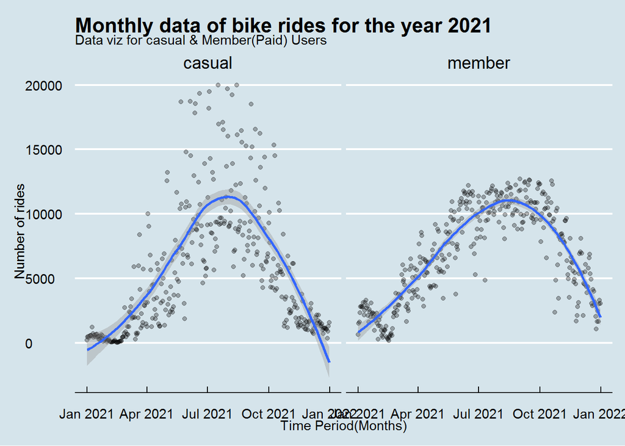

```r
ggplot(data=bike_ride_1) +
  geom_point(mapping = aes(x = start_date, y = number_of_rides),alpha = 0.3) +
  facet_wrap(~member_casual) +
  geom_smooth(mapping = aes(x = start_date, y = number_of_rides)) + theme_economist() +
  ggtitle("Monthly data of bike rides for the year 2021",subtitle = "Data viz for casual & Member(Paid) Users") +
  labs(x = "Time Period(Months)",y = "Number of rides")
```

Secondly we will visualize data on Time Period vs Average ride length

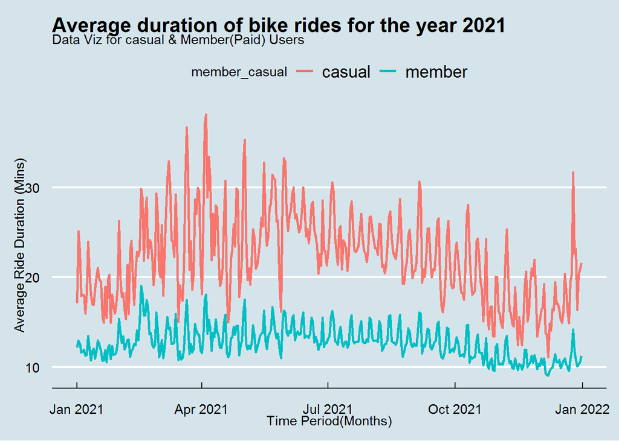

```r
ggplot(data=bike_ride_1) +
  geom_line(mapping = aes(x = start_date, y = Average_ride_Length,color = member_casual),size = 1) +
  theme_economist() +
  ggtitle("Average duration of bike rides for the year 2021",subtitle = "Data Viz for casual & Member(Paid) Users") +
  labs(x = "Time Period(Months)",y = "Average Ride Duration (Mins)")
```

ACT:

We can clearly see that the Casual Users of bike ride are more scattered around the month of *April* to *November*. Also the ride duration done by Casual users is considerably more than the Membership users. Therefor company should restrict the duration time for casual riders, after which they should be ask for plan upgrade for further riding.